# Analiza statystyczna na zbiorze Wine Quality

Maciej Paluch

31.08.2021

Załadowanie potrzebnych bibliotek:

```r
library(e1071) # do kurtozy
library(dplyr) # do lepszego zarzadzania danymi
library(ggplot2) # pakiet graficzny
library(ggcorrplot) # do korelacji
library(knitr) # tabelki
library(DT) # tabelki
```

Wczytanie zbioru danych i podglądnięcie tabeli z danymi (*interaktywna tabela*):

```r
danewina <- read.csv2("winequality.csv", header= T)
datatable(danewina, width = "100%", options=list(scrollX = T))
```

|  | region | color | fixed.acidity | volatile.acidity | citric.acid | residual.sugar | chlorides | free.sulfur.dioxide | total.sulfur.dioxide | density | pH | sulphates | sulphates.after.filtering | alcohol | quality |
| --- | --- | --- | --- | --- | --- | --- | --- | --- | --- | --- | --- | --- | --- | --- | --- |
| 1 | Bolonia | red | 7.4 | 0.7 | 0 | 1.9 | 0.076 | 11 | 34 | 0.9978 | 3.51 | 0.56 | 0.504 | 9.4 | 5 |
| 2 | Bolonia | red | 7.8 | 0.88 | 0 | 2.6 | 0.098 | 25 | 67 | 0.9968 | 3.2 | 0.68 | 0.612 | 9.8 | 5 |
| 3 | Bolonia | red | 7.8 | 0.76 | 0.04 | 2.3 | 0.092 | 15 | 54 | 0.997 | 3.26 | 0.65 | 0.585 | 9.8 | 5 |
| 4 | Emilia Romana | red | 11.2 | 0.28 | 0.56 | 1.9 | 0.075 | 17 | 60 | 0.998 | 3.16 | 0.58 | 0.522 | 9.8 | 6 |
| 5 | Bolonia | red | 7.4 | 0.7 | 0 | 1.9 | 0.076 | 11 | 34 | 0.9978 | 3.51 | 0.56 | 0.504 | 9.4 | 5 |
| 6 | Emilia Romana | red | 7.4 | 0.66 | 0 | 1.8 | 0.075 | 13 | 40 | 0.9978 | 3.51 | 0.56 | 0.504 | 9.4 | 5 |
| 7 | Emilia Romana | red | 7.9 | 0.6 | 0.06 | 1.6 | 0.069 | 15 | 59 | 0.9964 | 3.3 | 0.46 | 0.414 | 9.4 | 5 |
| 8 | Emilia Romana | red | 7.3 | 0.65 | 0 | 1.2 | 0.065 | 15 | 21 | 0.9946 | 3.39 | 0.47 | 0.423 | 10 | 7 |
| 9 | Bolonia | red | 7.8 | 0.58 | 0.02 | 2 | 0.073 | 9 | 18 | 0.9968 | 3.36 | 0.57 | 0.513 | 9.5 | 7 |
| 10 | Catania | red | 7.5 | 0.5 | 0.36 | 6.1 | 0.071 | 17 | 102 | 0.9978 | 3.35 | 0.8 | 0.72 | 10.5 | 5 |

[output cut: 6487 more lines]

Objaśnienie 15 zmiennych:

- **region** - *regiony włoskie*
- **color** - *kolor wina*
- **fixed.acidity** - *kwasowość pierwotna wina*
- **volatile.acidity** - *kwasowość powstała podczas procesu dojrzewania*
- **citric.acid** - *stężenie kwasu cytrynowego*
- **residual.sugar** - *zawartość cukru pozostała po procesie fermentacji*
- **chlorides** – *zawartość chlorku sodu*
- **free.sulfur.dioxide** - *zawartość wolnego dwutlenku siarki*
- **total.sulfur.dioxide** - *całkowita zawartość dwutlenku siarki*
- **density** – *gęstość wina*
- **pH** – *odczyn wina wyrażony przez poziom pH*
- **sulphates** - *zawartość siarczanu potasu*
- **sulphates.after.filtering** - *zawartość siarczanu potasu po filtracji*
- **alcohol** - *procentowa zawartość alkoholu*
- **quality** - *wynik oceny eksperckiej wina (w skali 0-10)*

## Analiza - **Spis Treści**

Analiza została przeprowadzona na podstawie zadań.  
Lista zadań:

- Scharakteryzuj 5 wybranych zmiennych: minimum, pierwszy kwartyl, medina, średnia, trzeci kwartyl, maksimum, odchylenie standardowe, wybraną miarę asymetrii i koncentracji w każdej z 6 grup: wina czerwone z Katanii, wina białe z Katanii, wina czerwone z Bolonii itd.
- Dla wybranych 4 zmiennych zrób wykres ramka-wąsy (boxplot). Niech kolor wina będzie tworzył serie. Dodał tytuł, opis osi, legendę.
- Dla wybranych 4 zmiennych zrób wykres ramka-wąsy (boxplot). Niech region Włoch będzie tworzył serie. Dodał tytuł, opis osi, legendę.
- Dla dwóch par wybranych zmiennych zrób wykres rozrzutu. Niech kolor wina będzie tworzył serie. Dodał tytuł, opis osi, legendę.
- Dla dwóch par wybranych zmiennych zrób wykres rozrzutu. Niech region Włoch będzie tworzył serie. Dodał tytuł, opis osi, legendę.
- Zbuduj 95% przedział ufności dla średniej i wariancji dla dwóch wybranych zmiennych dla wszystkich win ogółem oraz osobno dla win z Bolonii, Katanii i Emilii Romany.
- Sprawdź czy poziom siarki istotnie zmienił się po filtracji (zmienne sulphates i sulphates after filtering). Test wykonaj dla wszystkich win ogółem jak i w podziale na kolor wina.
- Wybierz 5 zmiennych charakterystyk wina. Sprawdź czy średni poziom każdej zmiennej różni się pomiędzy grupą win czerwonych a białych.
- Wybierz 5 zmiennych charakterystyk wina. Sprawdź czy wariancja każdej zmiennej różni się pomiędzy grupą win czerwonych a białych.
- Wybierz 5 zmiennych charakterystyk wina. Sprawdź czy średni poziom każdej zmiennej różni się pomiędzy regionami Włoch.
- Od czego zależy jakość wina? (zmienna quality) Użyj różnych pomysłów, metod i wizualizacji.

## Zadanie 1

- Scharakteryzuj 5 wybranych zmiennych: minimum, pierwszy kwartyl, medina, średnia, trzeci kwartyl, maksimum, odchylenie standardowe, wybraną miarę asymetrii i koncentracji w każdej z 6 grup: wina czerwone z Katanii, wina białe z Katanii, wina czerwone z Bolonii itd.

Wybrane zmienne:

- **pH** - *odczyn wina wyrażony przez poziom pH*
- **alcohol** - *procentowa zawartość alkoholu*
- **chlorides** - *zawartość chlorku sodu*
- **quality** - *wynik oceny ekspertów od wina (w skali 0-10)*
- **citric.acid** - *stężenie kwasu cytrynowego*

```r
Catania_Wine <- danewina[danewina$region == "Catania", ]
Bolonia_Wine <- danewina[danewina$region == "Bolonia", ]
EmiliaRomana_Wine <- danewina[danewina$region == "Emilia Romana", ]
```

Funkcja do wyboru regionu, interesującej nas zmiennej i wartości statystycznej (do agregacji):

```r
aggregateFunction <- function(x,y,z){
  aggregate(list("value"= x), list(Color=y), FUN= z)
}
```

Wyświetlenie funkcji dla wartości pH. W dalszych agregacjach zmienia się tylko odpowiednie parametry.  
(dlatego nie są wyświetlone kody do nich - dla przejrzystości raportu)

```r
# srednia
aggregateFunction(Bolonia_Wine$pH,  Bolonia_Wine$color, mean)
aggregateFunction(Catania_Wine$pH,  Catania_Wine$color, mean)
aggregateFunction(EmiliaRomana_Wine$pH,  EmiliaRomana_Wine$color, mean)

# mediana
aggregateFunction(Bolonia_Wine$pH,  Bolonia_Wine$color, median)
aggregateFunction(Catania_Wine$pH,  Catania_Wine$color, median)
aggregateFunction(EmiliaRomana_Wine$pH,  EmiliaRomana_Wine$color, median)

# kwantyle
aggregateFunction(Bolonia_Wine$pH,  Bolonia_Wine$color, quantile)
aggregateFunction(Catania_Wine$pH,  Catania_Wine$color, quantile)
aggregateFunction(EmiliaRomana_Wine$pH,  EmiliaRomana_Wine$color, quantile)

# wartosc min
aggregateFunction(Bolonia_Wine$pH,  Bolonia_Wine$color, min)
aggregateFunction(Catania_Wine$pH,  Catania_Wine$color, min)
aggregateFunction(EmiliaRomana_Wine$pH,  EmiliaRomana_Wine$color, min)

# wartosc max
aggregateFunction(Bolonia_Wine$pH,  Bolonia_Wine$color, max)
aggregateFunction(Catania_Wine$pH,  Catania_Wine$color, max)
aggregateFunction(EmiliaRomana_Wine$pH,  EmiliaRomana_Wine$color, max)

# odchylenie standardowe
aggregateFunction(Bolonia_Wine$pH,  Bolonia_Wine$color, sd)
aggregateFunction(Catania_Wine$pH,  Catania_Wine$color, sd)
aggregateFunction(EmiliaRomana_Wine$pH,  EmiliaRomana_Wine$color, sd)

# kurtoza
aggregateFunction(Bolonia_Wine$pH,  Bolonia_Wine$color, kurtosis)
aggregateFunction(Catania_Wine$pH,  Catania_Wine$color, kurtosis)
aggregateFunction(EmiliaRomana_Wine$pH,  EmiliaRomana_Wine$color, kurtosis)

# skosnosc - trzeci moment centralny
aggregateFunction(Bolonia_Wine$pH,  Bolonia_Wine$color, skewness)
aggregateFunction(Catania_Wine$pH,  Catania_Wine$color, skewness)
aggregateFunction(EmiliaRomana_Wine$pH,  EmiliaRomana_Wine$color, skewness)
```

### Dla wartości **pH**:

Parametry Statystyczne dla zmiennej **pH** w regionie **Bolonia**

| Kolor | Srednia | Mediana | 1.Kwartyl | 3.Kwartyl | Min | Max | OdchStand | Kurtoza | Skosnosc |
| --- | --- | --- | --- | --- | --- | --- | --- | --- | --- |
| red | 3.312410 | 3.31 | 3.21 | 3.4 | 2.74 | 3.90 | 0.1514665 | 0.4221712 | 0.1145628 |
| white | 3.207308 | 3.20 | 3.10 | 3.3 | 2.77 | 3.75 | 0.1512020 | 0.2374281 | 0.2953784 |

Parametry Statystyczne dla zmiennej **pH** w regionie **Catania**

| Kolor | Srednia | Mediana | 1.Kwartyl | 3.Kwartyl | Min | Max | OdchStand | Kurtoza | Skosnosc |
| --- | --- | --- | --- | --- | --- | --- | --- | --- | --- |
| red | 3.290805 | 3.30 | 3.20 | 3.38 | 2.98 | 3.58 | 0.1258295 | -0.4019733 | -0.1346111 |
| white | 3.167300 | 3.16 | 3.08 | 3.25 | 2.72 | 3.82 | 0.1417800 | 0.6259314 | 0.4638217 |

Parametry Statystyczne dla zmiennej **pH** w regionie **Emilia Romana**

| Kolor | Srednia | Mediana | 1.Kwartyl | 3.Kwartyl | Min | Max | OdchStand | Kurtoza | Skosnosc |
| --- | --- | --- | --- | --- | --- | --- | --- | --- | --- |
| red | 3.311880 | 3.32 | 3.2 | 3.41 | 2.86 | 4.01 | 0.1689181 | 1.415209 | 0.3745481 |
| white | 3.215596 | 3.21 | 3.1 | 3.32 | 2.74 | 3.81 | 0.1617499 | 0.432570 | 0.4339952 |

### Dla wartości **alcohol**:

Parametry Statystyczne dla zmiennej **alcohol** w regionie **Bolonia**

| Kolor | Srednia | Mediana | 1.Kwartyl | 3.Kwartyl | Min | Max | OdchStand | Kurtoza | Skosnosc |
| --- | --- | --- | --- | --- | --- | --- | --- | --- | --- |
| red | 10.45844 | 10.2 | 9.5 | 11.1 | 8.4 | 14 | 1.069283 | 0.0067919 | 0.8055947 |
| white | 11.30525 | 11.3 | 10.4 | 12.3 | 8.4 | 14 | 1.231523 | -0.9049161 | -0.1235458 |

Parametry Statystyczne dla zmiennej **alcohol** w regionie **Catania**

| Kolor | Srednia | Mediana | 1.Kwartyl | 3.Kwartyl | Min | Max | OdchStand | Kurtoza | Skosnosc |
| --- | --- | --- | --- | --- | --- | --- | --- | --- | --- |
| red | 10.59502 | 10.5 | 9.533333 | 11.2 | 8.8 | 14.90 | 1.191275 | 0.7035332 | 0.8269375 |
| white | 10.06764 | 9.7 | 9.200000 | 10.7 | 8.0 | 14.05 | 1.116616 | 0.1767042 | 0.9679575 |

Parametry Statystyczne dla zmiennej **alcohol** w regionie **Emilia Romana**

| Kolor | Srednia | Mediana | 1.Kwartyl | 3.Kwartyl | Min | Max | OdchStand | Kurtoza | Skosnosc |
| --- | --- | --- | --- | --- | --- | --- | --- | --- | --- |
| red | 10.27157 | 10.0 | 9.5 | 10.90 | 8.4 | 14.0 | 1.008544 | 0.5197576 | 1.0122887 |
| white | 10.82942 | 10.8 | 10.0 | 11.45 | 8.0 | 14.2 | 1.055224 | -0.4657661 | 0.2799252 |

### Dla wartości **chlorides**:

Parametry Statystyczne dla zmiennej **chlorides** w regionie **Bolonia**

| Kolor | Srednia | Mediana | 1.Kwartyl | 3.Kwartyl | Min | Max | OdchStand | Kurtoza | Skosnosc |
| --- | --- | --- | --- | --- | --- | --- | --- | --- | --- |
| red | 0.0860349 | 0.080 | 0.072 | 0.091 | 0.012 | 0.61 | 0.037512 | 61.78649 | 6.505329 |
| white | 0.0427297 | 0.039 | 0.033 | 0.047 | 0.012 | 0.24 | 0.021442 | 31.14294 | 4.837587 |

Parametry Statystyczne dla zmiennej **chlorides** w regionie **Catania**

| Kolor | Srednia | Mediana | 1.Kwartyl | 3.Kwartyl | Min | Max | OdchStand | Kurtoza | Skosnosc |
| --- | --- | --- | --- | --- | --- | --- | --- | --- | --- |
| red | 0.0912069 | 0.080 | 0.071 | 0.098 | 0.050 | 0.235 | 0.0371327 | 4.755622 | 2.158151 |
| white | 0.0471888 | 0.045 | 0.038 | 0.052 | 0.014 | 0.346 | 0.0205159 | 55.725233 | 5.929303 |

Parametry Statystyczne dla zmiennej **chlorides** w regionie **Emilia Romana**

| Kolor | Srednia | Mediana | 1.Kwartyl | 3.Kwartyl | Min | Max | OdchStand | Kurtoza | Skosnosc |
| --- | --- | --- | --- | --- | --- | --- | --- | --- | --- |
| red | 0.0910463 | 0.075 | 0.066 | 0.084 | 0.034 | 0.611 | 0.0701904 | 18.95325 | 4.164993 |
| white | 0.0451429 | 0.040 | 0.034 | 0.048 | 0.009 | 0.271 | 0.0242614 | 20.99898 | 4.088909 |

### Dla wartości **quality**:

Parametry Statystyczne dla zmiennej **quality** w regionie **Bolonia**

| Kolor | Srednia | Mediana | 1.Kwartyl | 3.Kwartyl | Min | Max | OdchStand | Kurtoza | Skosnosc |
| --- | --- | --- | --- | --- | --- | --- | --- | --- | --- |
| red | 5.636681 | 6 | 5 | 6 | 3 | 8 | 0.7893851 | 0.2354520 | 0.1844736 |
| white | 6.157051 | 6 | 6 | 7 | 3 | 9 | 0.9511679 | 0.2836353 | -0.1827279 |

Parametry Statystyczne dla zmiennej **quality** w regionie **Catania**

| Kolor | Srednia | Mediana | 1.Kwartyl | 3.Kwartyl | Min | Max | OdchStand | Kurtoza | Skosnosc |
| --- | --- | --- | --- | --- | --- | --- | --- | --- | --- |
| red | 5.724138 | 6 | 5 | 6 | 3 | 8 | 0.9607368 | -0.3533579 | 0.1752395 |
| white | 5.797396 | 6 | 5 | 6 | 3 | 9 | 0.8350149 | 0.3809388 | 0.3386658 |

Parametry Statystyczne dla zmiennej **quality** w regionie **Emilia Romana**

| Kolor | Srednia | Mediana | 1.Kwartyl | 3.Kwartyl | Min | Max | OdchStand | Kurtoza | Skosnosc |
| --- | --- | --- | --- | --- | --- | --- | --- | --- | --- |
| red | 5.613079 | 6 | 5 | 6 | 3 | 8 | 0.8249147 | 0.5157174 | 0.2929675 |
| white | 5.840118 | 6 | 5 | 6 | 3 | 9 | 0.8958611 | 0.1316467 | -0.0028826 |

### Dla wartości **citric.acid**:

Parametry Statystyczne dla zmiennej **citric.acid** w regionie **Bolonia**

| Kolor | Srednia | Mediana | 1.Kwartyl | 3.Kwartyl | Min | Max | OdchStand | Kurtoza | Skosnosc |
| --- | --- | --- | --- | --- | --- | --- | --- | --- | --- |
| red | 0.2732838 | 0.26 | 0.10 | 0.43 | 0 | 1.00 | 0.1952662 | -0.7859698 | 0.3156556 |
| white | 0.3178312 | 0.30 | 0.27 | 0.36 | 0 | 1.66 | 0.1070923 | 32.8351815 | 3.2992694 |

Parametry Statystyczne dla zmiennej **citric.acid** w regionie **Catania**

| Kolor | Srednia | Mediana | 1.Kwartyl | 3.Kwartyl | Min | Max | OdchStand | Kurtoza | Skosnosc |
| --- | --- | --- | --- | --- | --- | --- | --- | --- | --- |
| red | 0.3372414 | 0.34 | 0.19 | 0.455 | 0 | 0.78 | 0.2038564 | -0.7173157 | 0.2591322 |
| white | 0.3402604 | 0.31 | 0.26 | 0.400 | 0 | 1.00 | 0.1232746 | 2.5833781 | 1.1082348 |

Parametry Statystyczne dla zmiennej **citric.acid** w regionie **Emilia Romana**

| Kolor | Srednia | Mediana | 1.Kwartyl | 3.Kwartyl | Min | Max | OdchStand | Kurtoza | Skosnosc |
| --- | --- | --- | --- | --- | --- | --- | --- | --- | --- |
| red | 0.2480654 | 0.23 | 0.07 | 0.40 | 0 | 0.76 | 0.1874908 | -1.001612 | 0.2995886 |
| white | 0.3337972 | 0.32 | 0.27 | 0.39 | 0 | 1.00 | 0.1246834 | 2.948669 | 0.6647969 |

## Zadanie 2

- Dla wybranych 4 zmiennych zrób wykres ramka-wąsy (boxplot). Niech kolor wina będzie tworzył serie. Dodał tytuł, opis osi, legendę.

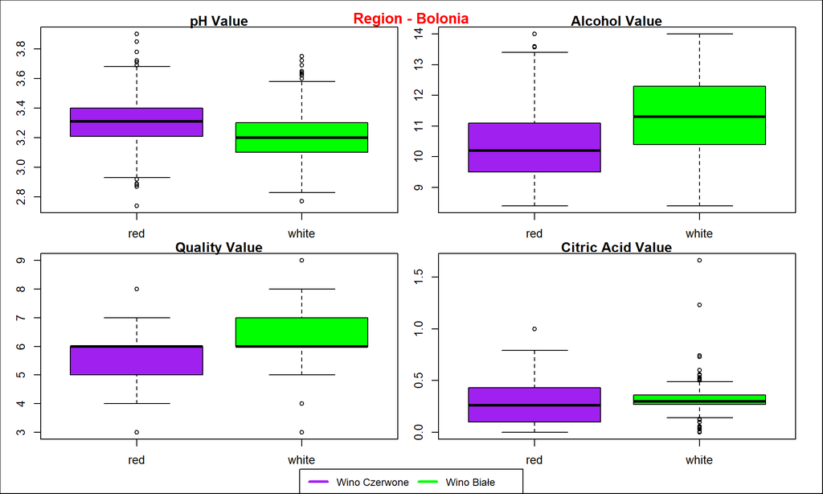

```r
### Region - Bolonia ----
par(oma = c(2,1,1,1), mfrow = c(2, 2), mar = c(2, 2, 1, 1))
for (i in 1:4){
  boxplot(Bolonia_Wine$pH ~ Bolonia_Wine$color, col=c("purple", "green"), main = "pH Value")
  boxplot(Bolonia_Wine$alcohol ~ Bolonia_Wine$color, col=c("purple", "green"), main = "Alcohol Value")
  boxplot(Bolonia_Wine$quality ~ Bolonia_Wine$color, col=c("purple", "green"), main = "Quality Value")
  boxplot(Bolonia_Wine$citric.acid ~ Bolonia_Wine$color, col=c("purple", "green"), main = "Citric Acid Value")
}
par(fig = c(0, 1, 0, 1), oma = c(0, 0, 0, 0), mar = c(0, 0, 0, 0), new = TRUE)
plot(0, 0, type = 'l', main ="\n\nRegion - Bolonia", col.main="red", cex.main=1.3)
legend( x ="bottom", legend = c("Wino Czerwone","Wino Białe"), col=c("purple", "green"),
        lty=c(1,1), lwd=3, cex=0.9, horiz=T,  bty = "o")
```

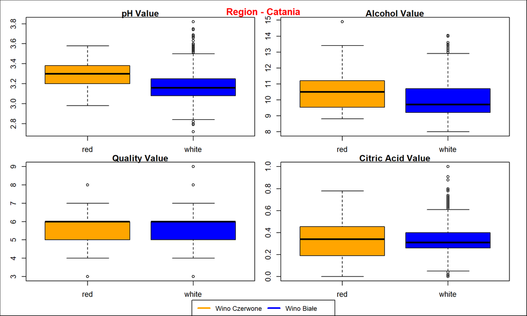

```r
### Region - Catania ----
par(oma = c(2,1,1,1), mfrow = c(2, 2), mar = c(2, 2, 1, 1))
for (i in 1:4){
  boxplot(Catania_Wine$pH ~ Catania_Wine$color, col=c("orange", "blue"), main = "pH Value")
  boxplot(Catania_Wine$alcohol ~ Catania_Wine$color, col=c("orange", "blue"), main = "Alcohol Value")
  boxplot(Catania_Wine$quality ~ Catania_Wine$color, col=c("orange", "blue"), main = "Quality Value")
  boxplot(Catania_Wine$citric.acid ~ Catania_Wine$color, col=c("orange", "blue"), main = "Citric Acid Value")
}
par(fig = c(0, 1, 0, 1), oma = c(0, 0, 0, 0), mar = c(0, 0, 0, 0), new = TRUE)
plot(0, 0, type = 'l', main ="\n\nRegion - Catania", col.main="red", cex.main=1.3)
legend( x ="bottom", legend = c("Wino Czerwone","Wino Białe"), col=c("orange", "blue"),
        lty=c(1,1), lwd=3, cex=0.9, horiz=T,  bty = "o")
```

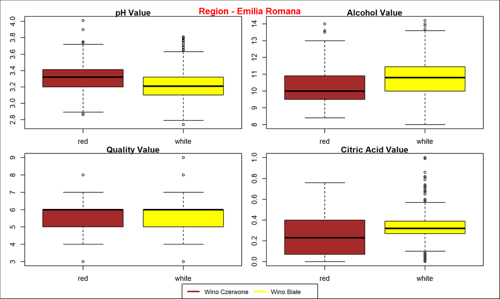

```r
### Region - Emilia Romana ----
par(oma = c(2,1,1,1), mfrow = c(2, 2), mar = c(2, 2, 1, 1))
for (i in 1:4){
  boxplot(EmiliaRomana_Wine$pH ~ EmiliaRomana_Wine$color, col=c("brown", "yellow"), main = "pH Value")
  boxplot(EmiliaRomana_Wine$alcohol ~ EmiliaRomana_Wine$color, col=c("brown", "yellow"), main = "Alcohol Value")
  boxplot(EmiliaRomana_Wine$quality ~ EmiliaRomana_Wine$color, col=c("brown", "yellow"), main = "Quality Value")
  boxplot(EmiliaRomana_Wine$citric.acid ~ EmiliaRomana_Wine$color, col=c("brown", "yellow"), main = "Citric Acid Value")
}
par(fig = c(0, 1, 0, 1), oma = c(0, 0, 0, 0), mar = c(0, 0, 0, 0), new = TRUE)
plot(0, 0, type = 'l', main ="\n\nRegion - Emilia Romana", col.main="red", cex.main=1.3)
legend( x ="bottom", legend = c("Wino Czerwone","Wino Białe"), col=c("brown", "yellow"),
        lty=c(1,1), lwd=3, cex=0.9, horiz=T,  bty = "o")
```

## Zadanie 3

- Dla wybranych 4 zmiennych zrób wykres ramka-wąsy (boxplot). Niech region Włoch będzie tworzył serie. Dodał tytuł, opis osi, legendę.

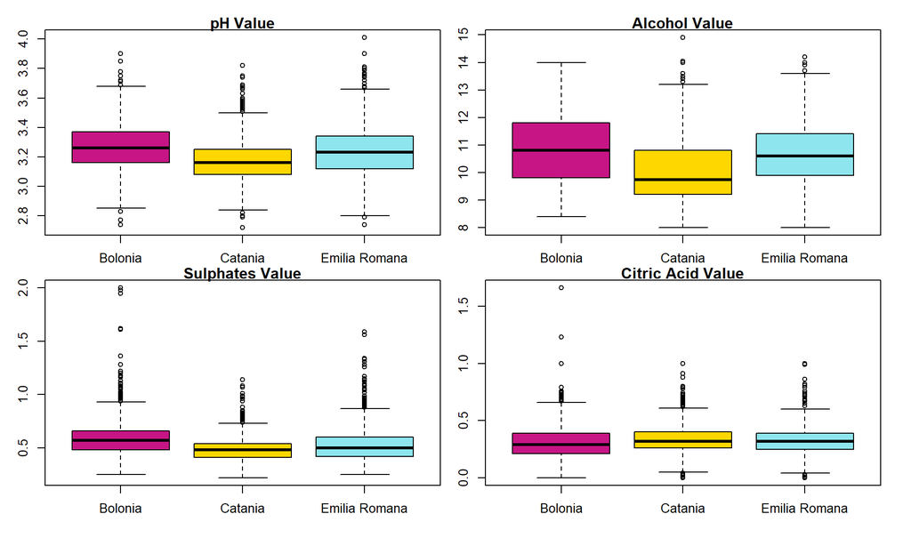

```r
par(oma = c(2,1,1,1), mfrow = c(2, 2), mar = c(2, 2, 1, 1))
for (i in 1:4){
  boxplot(danewina$pH ~ danewina$region, col=c("mediumvioletred", "gold1", "cadetblue2"), main = "pH Value", xlab="Color", ylab= "pH value")
  boxplot(danewina$alcohol ~ danewina$region, col=c("mediumvioletred", "gold1", "cadetblue2"), main = "Alcohol Value", xlab="Color", ylab= "Chlorides value")
  boxplot(danewina$sulphates ~ danewina$region, col=c("mediumvioletred", "gold1", "cadetblue2"), main = "Sulphates Value", xlab="Color", ylab= "Quality value")
  boxplot(danewina$citric.acid ~ danewina$region, col=c("mediumvioletred", "gold1", "cadetblue2"), main = "Citric Acid Value", xlab="Color", ylab= "Citric Acid value")

}
```

## Zadanie 4

- Dla dwóch par wybranych zmiennych zrób wykres rozrzutu. Niech kolor wina będzie tworzył serie. Dodał tytuł, opis osi, legendę.

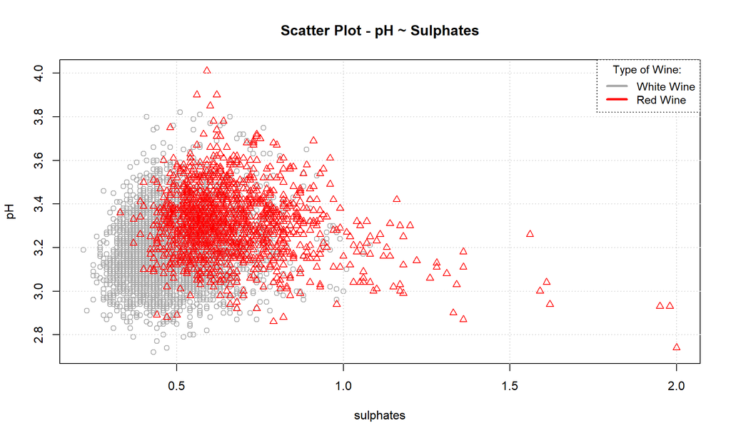

```r
par(mfrow=c(1,1))
plot(pH ~ sulphates, data = danewina[danewina$color == "white", ], col= "darkgrey",
     ylim=range(danewina$pH), xlim=range(danewina$sulphates), pch= 1,
     main = "Scatter Plot - pH ~ Sulphates")
points(pH ~ sulphates, data = danewina[danewina$color == "red", ], col= "red", pch= 2)
grid()
legend( x ="topright", legend = c("White Wine","Red Wine"),
        title ="Type of Wine: ", box.lty = 3,
        col=c("darkgrey","red"), lty=c(1,1),
        lwd=3, cex=0.9, horiz=F, bty = "o")
```

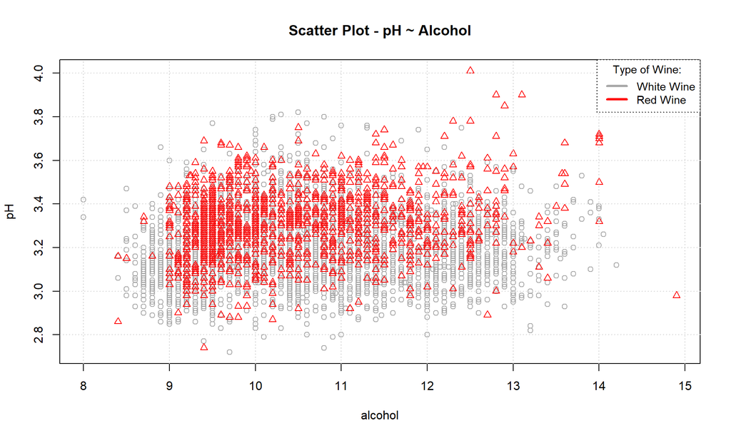

```r
par(mfrow=c(1,1))
plot(pH ~ alcohol, data = danewina[danewina$color == "white", ], col= "darkgrey",
     ylim=range(danewina$pH), xlim=range(danewina$alcohol), pch= 1,
     main = "Scatter Plot - pH ~ Alcohol")
points(pH ~ alcohol, data = danewina[danewina$color == "red", ], col= "red", pch= 2)
grid()
legend( x ="topright", legend = c("White Wine","Red Wine"),
        title ="Type of Wine: ", box.lty = 3,
        col=c("darkgrey","red"), lty=c(1,1),
        lwd=3, cex=0.9, horiz=F, bty = "o")
```

## Zadanie 5

- Dla dwóch par wybranych zmiennych zrób wykres rozrzutu. Niech region Włoch będzie tworzył serie. Dodał tytuł, opis osi, legendę.

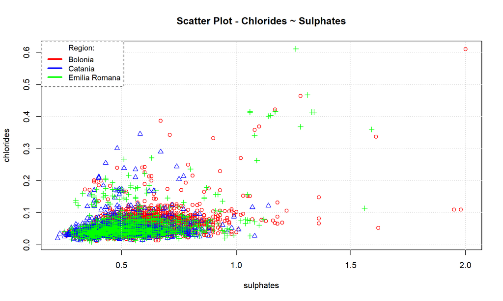

```r
par(mfrow=c(1,1))
plot(chlorides ~ sulphates, data = danewina[danewina$region == "Bolonia", ], col= "red",
     ylim=range(danewina$chlorides), xlim=range(danewina$sulphates), pch= 1,
     main = "Scatter Plot - Chlorides ~ Sulphates")
points(chlorides ~ sulphates, data = danewina[danewina$region == "Catania", ], col= "blue", pch= 2)
points(chlorides ~ sulphates, data = danewina[danewina$region == "Emilia Romana", ], col= "green", pch= 3)
grid()
legend( x ="topleft", legend = c("Bolonia","Catania", "Emilia Romana"),
        title ="Region: ", box.lty = 2,
        col=c("red","blue", "green"), lty=c(1,1,1),
        lwd=3, cex=0.9, horiz=F, bty = "o")
```

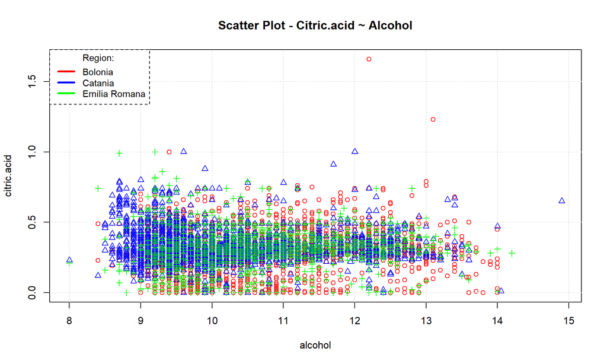

```r
par(mfrow=c(1,1))
plot(citric.acid ~ alcohol, data = danewina[danewina$region == "Bolonia", ], col= "red",
     ylim=range(danewina$citric.acid), xlim=range(danewina$alcohol), pch= 1,
     main = "Scatter Plot - Citric.acid ~ Alcohol")
points(citric.acid ~ alcohol, data = danewina[danewina$region == "Catania", ], col= "blue", pch= 2)
points(citric.acid ~ alcohol, data = danewina[danewina$region == "Emilia Romana", ], col= "green", pch= 3)
grid()
legend( x ="topleft", legend = c("Bolonia","Catania", "Emilia Romana"),
        title ="Region: ", box.lty = 2,
        col=c("red","blue", "green"), lty=c(1,1,1),
        lwd=3, cex=0.9, horiz=F, bty = "o")
```

## Zadanie 6

- Zbuduj 95% przedział ufności dla średniej i wariancji dla dwóch wybranych zmiennych dla wszystkich win ogółem oraz osobno dla win z Bolonii, Katanii i Emilii Romany.

```r
### test dla sredniej ----

# dla ogolnych danych
wines_ttest <- t.test(x = danewina$pH, y= danewina$citric.acid, conf.level = 0.95)

# dla regionu Bolonia
winesB_ttest <- t.test(x = Bolonia_Wine$pH, y= Bolonia_Wine$citric.acid, conf.level = 0.95)

# dla regionu Catania
winesC_ttest <- t.test(x = Catania_Wine$pH, y= Catania_Wine$citric.acid, conf.level = 0.95)

# dla regionu Emilia Romana
winesER_ttest <- t.test(x = EmiliaRomana_Wine$pH, y= EmiliaRomana_Wine$citric.acid,conf.level = 0.95)

# Ramka danych dla przedzialu wariancji
meanintervaldf <- data.frame( c("Ogółem","Bolonia","Catania","Emilia Romana"),
                              c(round(wines_ttest$conf.int[1],5), round(winesB_ttest$conf.int[1],5),
                                round(winesC_ttest$conf.int[1],5), round(winesER_ttest$conf.int[1],5)),
                              c(round(wines_ttest$conf.int[2],5), round(winesB_ttest$conf.int[2],5),
                                round(winesC_ttest$conf.int[2],5), round(winesER_ttest$conf.int[2],5)))

names(meanintervaldf) <- c("Region:","Min","Max")

meanintervaldf
```

```
##         Region:     Min     Max
## 1        Ogółem 2.89460 2.90514
## 2       Bolonia 2.96199 2.98164
## 3       Catania 2.82391 2.83833
## 4 Emilia Romana 2.91019 2.93117
```

```r
### test dla wariancji ----

# dla ogolnych danych
wines_vartest <- var.test(x = danewina$pH, y= danewina$citric.acid, conf.level =0.95)

# Dla regionu Bolonia
winesB_vartest <- var.test(x = Bolonia_Wine$pH, y= Bolonia_Wine$citric.acid, conf.level =0.95)

# Dla regionu Catania
winesC_vartest <- var.test(x = Catania_Wine$pH, y= Catania_Wine$citric.acid, conf.level =0.95)

# Dla regionu Emilia Romana
winesER_vartest <- var.test(x = EmiliaRomana_Wine$pH, y= EmiliaRomana_Wine$citric.acid, conf.level =0.95)

# Ramka danych dla przedzialu wariancji
varintervaldf <- data.frame( c("Ogółem","Bolonia","Catania","Emilia Romana"),
                             c(round(wines_vartest$conf.int[1],5), round(winesB_vartest$conf.int[1],5),
                               round(winesC_vartest$conf.int[1],5), round(winesER_vartest$conf.int[1],5)),
                             c(round(wines_vartest$conf.int[2],5), round(winesB_vartest$conf.int[2],5),
                               round(winesC_vartest$conf.int[2],5), round(winesER_vartest$conf.int[2],5)))

names(varintervaldf) <- c("Region:","Min","Max")

varintervaldf
```

```
##         Region:     Min     Max
## 1        Ogółem 1.16611 1.28525
## 2       Bolonia 0.88358 1.04935
## 3       Catania 1.18191 1.37455
## 4 Emilia Romana 1.22491 1.48013
```

## Zadanie 7

- Sprawdź czy poziom siarki istotnie zmienił się po filtracji (zmienne sulphates i sulphates after filtering). Test wykonaj dla wszystkich win ogółem jak i w podziale na kolor wina.

```r
# ogolne dane
t.test(x = danewina$sulphates,
       y = danewina$sulphates.after.filtering,
       conf.level = 0.95)
```

```
##
##  Welch Two Sample t-test
##
## data:  danewina$sulphates and danewina$sulphates.after.filtering
## t = 21.39, df = 12850, p-value < 2.2e-16
## alternative hypothesis: true difference in means is not equal to 0
## 95 percent confidence interval:
##  0.04825836 0.05799529
## sample estimates:
## mean of x mean of y
## 0.5312683 0.4781414
```

```r
# wino biale
t.test(x = danewina$sulphates[danewina$color == "white"],
       y = danewina$sulphates.after.filtering[danewina$color == "white"],
       conf.level = 0.95)
```

```
##
##  Welch Two Sample t-test
##
## data:  danewina$sulphates[danewina$color == "white"] and danewina$sulphates.after.filtering[danewina$color == "white"]
## t = 22.328, df = 9687.3, p-value < 2.2e-16
## alternative hypothesis: true difference in means is not equal to 0
## 95 percent confidence interval:
##  0.04468421 0.05328516
## sample estimates:
## mean of x mean of y
## 0.4898469 0.4408622
```

```r
# wino czerwone
t.test(x = danewina$sulphates[danewina$color == "red"],
       y = danewina$sulphates.after.filtering[danewina$color == "red"],
       conf.level = 0.95)
```

```
##
##  Welch Two Sample t-test
##
## data:  danewina$sulphates[danewina$color == "red"] and danewina$sulphates.after.filtering[danewina$color == "red"]
## t = 11.54, df = 3161.2, p-value < 2.2e-16
## alternative hypothesis: true difference in means is not equal to 0
## 95 percent confidence interval:
##  0.05463295 0.07699682
## sample estimates:
## mean of x mean of y
## 0.6581488 0.5923340
```

**Wniosek:** We wszystkich przypadkach mamy podstawy do odrzucenia hipotezy zerowej mówiącej że średnia przed filtracją jest równa średniej po filtracji. (Zwracamy uwagę na wartość *p*. Jest ona mniejsza od *0.05* [przedział ufności ustawiony na *0.95*], a więc odrzucamy hipotezę zerową). Oznacza to że średnie każdego z ww. przypadków istotnie różnią się od siebie - a więc również i poziom zmienił się istotnie.

## Zadanie 8

- Wybierz 5 zmiennych charakterystyk wina. Sprawdź czy średni poziom każdej zmiennej różni się pomiędzy grupą win czerwonych a białych.

```r
## zmienna Sulphates
t.test(danewina$sulphates[danewina$color == "white"], danewina$sulphates[danewina$color == "red"],
       conf.level = 0.95)
```

```
##
##  Welch Two Sample t-test
##
## data:  danewina$sulphates[danewina$color == "white"] and danewina$sulphates[danewina$color == "red"]
## t = -37.056, df = 2091, p-value < 2.2e-16
## alternative hypothesis: true difference in means is not equal to 0
## 95 percent confidence interval:
##  -0.177209 -0.159395
## sample estimates:
## mean of x mean of y
## 0.4898469 0.6581488
```

```r
## zmienna pH
t.test(danewina$pH[danewina$color == "white"], danewina$pH[danewina$color == "red"],
       conf.level = 0.95)
```

```
##
##  Welch Two Sample t-test
##
## data:  danewina$pH[danewina$color == "white"] and danewina$pH[danewina$color == "red"]
## t = -27.775, df = 2667.1, p-value < 2.2e-16
## alternative hypothesis: true difference in means is not equal to 0
## 95 percent confidence interval:
##  -0.1315191 -0.1141740
## sample estimates:
## mean of x mean of y
##  3.188267  3.311113
```

```r
## zmienna Alcohol
t.test(danewina$alcohol[danewina$color == "white"], danewina$alcohol[danewina$color == "red"],
       conf.level = 0.95)
```

```
##
##  Welch Two Sample t-test
##
## data:  danewina$alcohol[danewina$color == "white"] and danewina$alcohol[danewina$color == "red"]
## t = 2.859, df = 3100.5, p-value = 0.004278
## alternative hypothesis: true difference in means is not equal to 0
## 95 percent confidence interval:
##  0.02868117 0.15388669
## sample estimates:
## mean of x mean of y
##  10.51427  10.42298
```

```r
## zmienna Citric.acid
t.test(x = danewina$citric.acid[danewina$color == "white"], danewina$citric.acid[danewina$color == "red"],
       conf.level = 0.95)
```

```
##
##  Welch Two Sample t-test
##
## data:  danewina$citric.acid[danewina$color == "white"] and danewina$citric.acid[danewina$color == "red"]
## t = 12.229, df = 2015.6, p-value < 2.2e-16
## alternative hypothesis: true difference in means is not equal to 0
## 95 percent confidence interval:
##  0.05307807 0.07335372
## sample estimates:
## mean of x mean of y
## 0.3341915 0.2709756
```

```r
## zmienna Quality
t.test(x = danewina$quality[danewina$color == "white"], danewina$quality[danewina$color == "red"],
       conf.level = 0.95)
```

```
##
##  Welch Two Sample t-test
##
## data:  danewina$quality[danewina$color == "white"] and danewina$quality[danewina$color == "red"]
## t = 10.149, df = 2950.8, p-value < 2.2e-16
## alternative hypothesis: true difference in means is not equal to 0
## 95 percent confidence interval:
##  0.1951564 0.2886173
## sample estimates:
## mean of x mean of y
##  5.877909  5.636023
```

**Wniosek:** We wszystkich przypadkach mamy podstawy do odrzucenia hipotezy zerowej mowiącej że różnica średnich każdej badanej pary zmiennych wynosi 0 (średnie są sobie równe).  
Jak można zauważyć, wartości parametru *p* są bardzo małe w większości wyników. Wyjątkiem jest test dla zmiennej Alcohol, gdzie wartość *p* wynosi *0.004278*. Jest to jednak dalej wartość mniejsza od *0.05* - a więc również są podstawy do odrzucenia hipotezy zerowej.

## Zadanie 9

- Wybierz 5 zmiennych charakterystyk wina. Sprawdź czy wariancja każdej zmiennej różni się pomiędzy grupą win czerwonych a białych.

```r
## Zmienna Quality
var.test(danewina$quality[danewina$color=="red"], danewina$quality[danewina$color== "white"])
```

```
##
##  F test to compare two variances
##
## data:  danewina$quality[danewina$color == "red"] and danewina$quality[danewina$color == "white"]
## F = 0.83147, num df = 1598, denom df = 4897, p-value = 8.561e-06
## alternative hypothesis: true ratio of variances is not equal to 1
## 95 percent confidence interval:
##  0.7682689 0.9013500
## sample estimates:
## ratio of variances
##          0.8314702
```

```r
## Zmienna pH
var.test(danewina$pH[danewina$color=="red"], danewina$pH[danewina$color== "white"])
```

```
##
##  F test to compare two variances
##
## data:  danewina$pH[danewina$color == "red"] and danewina$pH[danewina$color == "white"]
## F = 1.0453, num df = 1598, denom df = 4897, p-value = 0.2716
## alternative hypothesis: true ratio of variances is not equal to 1
## 95 percent confidence interval:
##  0.965890 1.133203
## sample estimates:
## ratio of variances
##           1.045349
```

```r
## Zmienna Chlorides
var.test(danewina$chlorides[danewina$color=="red"], danewina$chlorides[danewina$color== "white"])
```

```
##
##  F test to compare two variances
##
## data:  danewina$chlorides[danewina$color == "red"] and danewina$chlorides[danewina$color == "white"]
## F = 4.6407, num df = 1598, denom df = 4897, p-value < 2.2e-16
## alternative hypothesis: true ratio of variances is not equal to 1
## 95 percent confidence interval:
##  4.287915 5.030676
## sample estimates:
## ratio of variances
##           4.640658
```

```r
## Zmienna Sulphates
var.test(danewina$sulphates[danewina$color=="red"], danewina$sulphates[danewina$color== "white"])
```

```
##
##  F test to compare two variances
##
## data:  danewina$sulphates[danewina$color == "red"] and danewina$sulphates[danewina$color == "white"]
## F = 2.206, num df = 1598, denom df = 4897, p-value < 2.2e-16
## alternative hypothesis: true ratio of variances is not equal to 1
## 95 percent confidence interval:
##  2.038327 2.391410
## sample estimates:
## ratio of variances
##           2.206009
```

```r
## Zmienna Density
var.test(danewina$density[danewina$color=="red"], danewina$density[danewina$color== "white"])
```

```
##
##  F test to compare two variances
##
## data:  danewina$density[danewina$color == "red"] and danewina$density[danewina$color == "white"]
## F = 0.39819, num df = 1598, denom df = 4897, p-value < 2.2e-16
## alternative hypothesis: true ratio of variances is not equal to 1
## 95 percent confidence interval:
##  0.3679241 0.4316567
## sample estimates:
## ratio of variances
##          0.3981912
```

**Wniosek:** Wartość *p* dla testu zmiennej pH wynosi *0.2716* i jest większa od poziomu istotności *0.05*. W takim przypadku pozostajemy przy hipotezie zerowej mówiącej że współczynnik wariancji jest równy 1.  
Podsumowując, nie ma istotnej różnicy pomiędzy obiema wariancjami dla koloru wina i zmiennej pH.  
W pozostałych przypadkach odrzucamy hipotezę zerową - jest istotna różnica pomiędzy wariancjami.

## Zadanie 10

- Wybierz 5 zmiennych charakterystyk wina. Sprawdź czy średni poziom każdej zmiennej różni się pomiędzy regionami Włoch.

### *Catania - Bolonia*

```r
t.test(Catania_Wine$sulphates, Bolonia_Wine$sulphates)
```

```
##
##  Welch Two Sample t-test
##
## data:  Catania_Wine$sulphates and Bolonia_Wine$sulphates
## t = -22.883, df = 3484.2, p-value < 2.2e-16
## alternative hypothesis: true difference in means is not equal to 0
## 95 percent confidence interval:
##  -0.10594675 -0.08922395
## sample estimates:
## mean of x mean of y
## 0.4899110 0.5874964
```

```r
t.test(Catania_Wine$pH, Bolonia_Wine$pH)
```

```
##
##  Welch Two Sample t-test
##
## data:  Catania_Wine$pH and Bolonia_Wine$pH
## t = -21.044, df = 4199.9, p-value < 2.2e-16
## alternative hypothesis: true difference in means is not equal to 0
## 95 percent confidence interval:
##  -0.10259815 -0.08511089
## sample estimates:
## mean of x mean of y
##  3.171282  3.265137
```

```r
t.test(Catania_Wine$alcohol, Bolonia_Wine$alcohol)
```

```
##
##  Welch Two Sample t-test
##
## data:  Catania_Wine$alcohol and Bolonia_Wine$alcohol
## t = -21.948, df = 4277.6, p-value < 2.2e-16
## alternative hypothesis: true difference in means is not equal to 0
## 95 percent confidence interval:
##  -0.8220888 -0.6872636
## sample estimates:
## mean of x mean of y
##  10.08465  10.83932
```

```r
t.test(Catania_Wine$citric.acid, Bolonia_Wine$citric.acid)
```

```
##
##  Welch Two Sample t-test
##
## data:  Catania_Wine$citric.acid and Bolonia_Wine$citric.acid
## t = 10.823, df = 3824.9, p-value < 2.2e-16
## alternative hypothesis: true difference in means is not equal to 0
## 95 percent confidence interval:
##  0.03835685 0.05532828
## sample estimates:
## mean of x mean of y
## 0.3401631 0.2933205
```

```r
t.test(Catania_Wine$quality, Bolonia_Wine$quality)
```

```
##
##  Welch Two Sample t-test
##
## data:  Catania_Wine$quality and Bolonia_Wine$quality
## t = -2.9615, df = 4300.5, p-value = 0.003078
## alternative hypothesis: true difference in means is not equal to 0
## 95 percent confidence interval:
##  -0.12581615 -0.02558758
## sample estimates:
## mean of x mean of y
##  5.795033  5.870735
```

**Wniosek:** Dla każdego testu wartość *p* okazała się być bardzo mała. Odrzucamy hipotezę zerową mówiącą że różnica średnich wynosi 0. Odpowiedź - średni poziom różni się istotnie statystycznie.

### *Catania - Emilia Romana*

```r
t.test(Catania_Wine$sulphates, EmiliaRomana_Wine$sulphates)
```

```
##
##  Welch Two Sample t-test
##
## data:  Catania_Wine$sulphates and EmiliaRomana_Wine$sulphates
## t = -8.9344, df = 2914.1, p-value < 2.2e-16
## alternative hypothesis: true difference in means is not equal to 0
## 95 percent confidence interval:
##  -0.04658017 -0.02981427
## sample estimates:
## mean of x mean of y
## 0.4899110 0.5281083
```

```r
t.test(Catania_Wine$pH, EmiliaRomana_Wine$pH)
```

```
##
##  Welch Two Sample t-test
##
## data:  Catania_Wine$pH and EmiliaRomana_Wine$pH
## t = -13.245, df = 3228.8, p-value < 2.2e-16
## alternative hypothesis: true difference in means is not equal to 0
## 95 percent confidence interval:
##  -0.07448610 -0.05527732
## sample estimates:
## mean of x mean of y
##  3.171282  3.236164
```

```r
t.test(Catania_Wine$alcohol, EmiliaRomana_Wine$alcohol)
```

```
##
##  Welch Two Sample t-test
##
## data:  Catania_Wine$alcohol and EmiliaRomana_Wine$alcohol
## t = -18.582, df = 3784.6, p-value < 2.2e-16
## alternative hypothesis: true difference in means is not equal to 0
## 95 percent confidence interval:
##  -0.6916135 -0.5595990
## sample estimates:
## mean of x mean of y
##  10.08465  10.71025
```

```r
t.test(Catania_Wine$citric.acid, EmiliaRomana_Wine$citric.acid)
```

```
##
##  Welch Two Sample t-test
##
## data:  Catania_Wine$citric.acid and EmiliaRomana_Wine$citric.acid
## t = 5.795, df = 3299.2, p-value = 7.474e-09
## alternative hypothesis: true difference in means is not equal to 0
## 95 percent confidence interval:
##  0.01632976 0.03303016
## sample estimates:
## mean of x mean of y
## 0.3401631 0.3154831
```

```r
t.test(Catania_Wine$quality, EmiliaRomana_Wine$quality)
```

```
##
##  Welch Two Sample t-test
##
## data:  Catania_Wine$quality and EmiliaRomana_Wine$quality
## t = 0.12747, df = 3510.5, p-value = 0.8986
## alternative hypothesis: true difference in means is not equal to 0
## 95 percent confidence interval:
##  -0.0491154  0.0559458
## sample estimates:
## mean of x mean of y
##  5.795033  5.791618
```

### *Emilia Romana - Bolonia*

```r
t.test(EmiliaRomana_Wine$sulphates, Bolonia_Wine$sulphates)
```

```
##
##  Welch Two Sample t-test
##
## data:  EmiliaRomana_Wine$sulphates and Bolonia_Wine$sulphates
## t = -11.447, df = 3759.8, p-value < 2.2e-16
## alternative hypothesis: true difference in means is not equal to 0
## 95 percent confidence interval:
##  -0.06955960 -0.04921666
## sample estimates:
## mean of x mean of y
## 0.5281083 0.5874964
```

```r
t.test(EmiliaRomana_Wine$pH, Bolonia_Wine$pH)
```

```
##
##  Welch Two Sample t-test
##
## data:  EmiliaRomana_Wine$pH and Bolonia_Wine$pH
## t = -5.4047, df = 3591, p-value = 6.916e-08
## alternative hypothesis: true difference in means is not equal to 0
## 95 percent confidence interval:
##  -0.03948317 -0.01846245
## sample estimates:
## mean of x mean of y
##  3.236164  3.265137
```

```r
t.test(EmiliaRomana_Wine$alcohol, Bolonia_Wine$alcohol)
```

```
##
##  Welch Two Sample t-test
##
## data:  EmiliaRomana_Wine$alcohol and Bolonia_Wine$alcohol
## t = -3.4727, df = 3783.2, p-value = 0.000521
## alternative hypothesis: true difference in means is not equal to 0
## 95 percent confidence interval:
##  -0.20193879 -0.05620096
## sample estimates:
## mean of x mean of y
##  10.71025  10.83932
```

```r
t.test(EmiliaRomana_Wine$citric.acid, Bolonia_Wine$citric.acid)
```

```
##
##  Welch Two Sample t-test
##
## data:  EmiliaRomana_Wine$citric.acid and Bolonia_Wine$citric.acid
## t = 4.4337, df = 3777.4, p-value = 9.525e-06
## alternative hypothesis: true difference in means is not equal to 0
## 95 percent confidence interval:
##  0.01236234 0.03196286
## sample estimates:
## mean of x mean of y
## 0.3154831 0.2933205
```

```r
t.test(EmiliaRomana_Wine$quality, Bolonia_Wine$quality)
```

```
##
##  Welch Two Sample t-test
##
## data:  EmiliaRomana_Wine$quality and Bolonia_Wine$quality
## t = -2.7151, df = 3687.6, p-value = 0.006656
## alternative hypothesis: true difference in means is not equal to 0
## 95 percent confidence interval:
##  -0.13624829 -0.02198583
## sample estimates:
## mean of x mean of y
##  5.791618  5.870735
```

**Wniosek:** Dla każdego testu wartość *p* okazała się być bardzo mała. Odrzucamy hipotezę zerową mówiącą że różnica średnich wynosi 0. Odpowiedź - średni poziom różni się istotnie statystycznie.

## Zadanie 11

- Od czego zależy jakość wina? (zmienna quality) Użyj różnych pomysłów, metod i wizualizacji.

### *Korelacja*

Do analizy korelacji potrzebujemy danych typu numeric i oczyszczonych z braków danych ( *NA* ).

```r
wine_numeric <- select_if(danewina, is.numeric)
res <- as.data.frame(cor(na.omit(wine_numeric)))
```

Sprawdzenie korelacji pomiędzy zmiennymi:

- Współczynnik korelacji R zawiera się w przedziale *[-1; 1]*
  - **korelacja dodatnia** - informacja, że wzrostowi wartości jednej cechy towarzyszy wzrost wartości drugiej cechy
  - **korelacja ujemna** - informacja, że wzrostowi wartości jednej cechy towarzyszy spadek wartości drugiej cechy
- Siła związku pomiędzy zmiennymi:
  - od *0* do *0.3* - słaby związek
  - od *0.3* do *0.5* - związek umiarkowanie silny
  - od *0.5* do *1* - związek silny lub bardzo silny

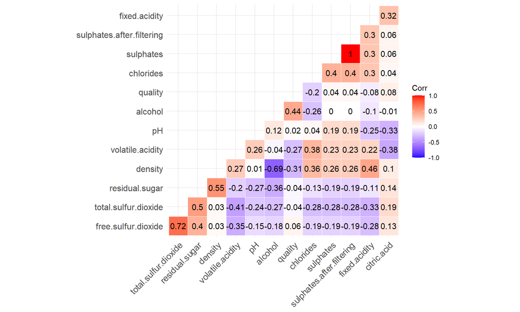

```r
ggcorrplot(res, hc.order= T, type= "lower", outline.color = "white", lab= T)
```

Odczytujemy z korelogramu interesującą nas zmienną - w naszym przypadku zmienna *Quality*.  
Możemy zauważyć że istotnie zmienna *Quality* skorelowana jest ze zmiennymi:

- *Alcohol* (współczynnik korelacji równy *0.44*)
- *Density* (współczynnik korelacji równy *-0.31*)

Oznacza to że są to umiarkowanie silne powiązania pomiędzy tymi zmiennymi.

### *Zależność od rodzaju wina*

Sprawdzimy, czy jakość wina zależy od jego rodzaju (koloru).  
Tabelka, która ukazuje liczbę win o danej wartości jakości, z ograniczeniem na kolor wina:

```r
freqcolordf <- data.frame(table(danewina$quality[danewina$color=="white"]),
           table(factor(danewina$quality[danewina$color=="red"], levels=3:9)))

freqcolordf <- freqcolordf[,c(2,4)]
names(freqcolordf) <- c("white","red")
rownames(freqcolordf) <- 3:9
datatable(freqcolordf)
```

|  | white | red |
| --- | --- | --- |
| 3 | 20 | 10 |
| 4 | 163 | 53 |
| 5 | 1457 | 681 |
| 6 | 2198 | 638 |
| 7 | 880 | 199 |
| 8 | 175 | 18 |
| 9 | 5 | 0 |

```r
chisq.test(unlist(danewina$quality[danewina$color=="red"]),unlist(danewina$quality[danewina$color=="red"]))
```

```
##
##  Pearson's Chi-squared test
##
## data:  unlist(danewina$quality[danewina$color == "red"]) and unlist(danewina$quality[danewina$color == "red"])
## X-squared = 7995, df = 25, p-value < 2.2e-16
```

### *Zależność od regionu pochodzenia*

Sprawdzimy, czy jakość wina zależy od jego regionu.  
Tabelki, które ukazują liczbę win o danej wartości jakości, oraz ich procentowy udział z ograniczeniem na 3 regiony:

```r
qualCat <- as.data.frame(table(Catania_Wine$quality))
qualBol <- as.data.frame(table(Bolonia_Wine$quality))
qualEmiR <- as.data.frame(table(EmiliaRomana_Wine$quality))

qualData <- qualCat
qualData <- cbind(qualData, qualBol$Freq)
qualData <- cbind(qualData, qualEmiR$Freq)

row.names(qualData) <- qualData$Var1
qualData <- qualData[,2:4]
names(qualData) <- c("Catania","Bolonia","Emilia Romana")

## Funkcja zamiany wartosci na procenty w zaleznosci od wierszy
percentSumRows <- function(x){

  percentqualData <- data.frame(matrix(NA, ncol = ncol(x)))

  for (i in 1:nrow(x)){
    percentqualData <- rbind(percentqualData, paste0(round(as.numeric(x[i,]/rowSums(x[i,]))*100,1),"%"))
  }

  ## Wynik procentowy jakosci wina z podzialem na regiony
  percentqualData <- percentqualData[2:8,]
  row.names(percentqualData) <- row.names(x)
  names(percentqualData) <- names(x)
  return(percentqualData)
}

datatable(qualData)
```

|  | Catania | Bolonia | Emilia Romana |
| --- | --- | --- | --- |
| 3 | 10 | 11 | 9 |
| 4 | 64 | 71 | 81 |
| 5 | 947 | 644 | 547 |
| 6 | 1208 | 880 | 748 |
| 7 | 387 | 403 | 289 |
| 8 | 81 | 69 | 43 |
| 9 | 1 | 3 | 1 |

```r
datatable(percentSumRows(qualData), options = list(
            columnDefs = list(list(className = 'dt-right', targets = 1:3))
            ))
```

|  | Catania | Bolonia | Emilia Romana |
| --- | --- | --- | --- |
| 3 | 33.3% | 36.7% | 30% |
| 4 | 29.6% | 32.9% | 37.5% |
| 5 | 44.3% | 30.1% | 25.6% |
| 6 | 42.6% | 31% | 26.4% |
| 7 | 35.9% | 37.3% | 26.8% |
| 8 | 42% | 35.8% | 22.3% |
| 9 | 20% | 60% | 20% |

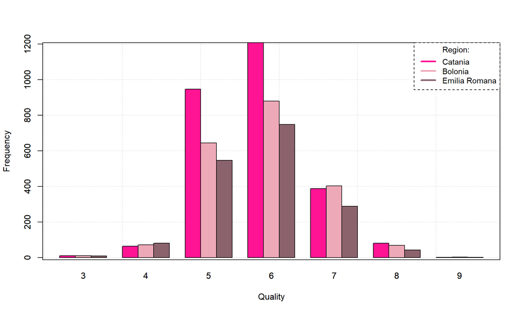

```r
barplot(t(qualData[c("Catania", "Bolonia", "Emilia Romana")]),
        beside= T, ylab= "Frequency", xlab= "Quality")
grid()
barplot(t(qualData[c("Catania", "Bolonia", "Emilia Romana")]),
        beside= T, ylab= "Frequency", xlab= "Quality", add = T,
        col= c("deeppink","pink2", "pink4"))
box()
legend(x ="topright", legend = c("Catania","Bolonia", "Emilia Romana"),
        title ="Region: ", box.lty = 2,
        col= c("deeppink","pink2", "pink4"), lty=c(1,1,1),
        lwd=3, cex=0.9, horiz=F, bty = "o")
```